# Lesson_6*

Представлены данные взаимодействий с рекламными объявлениями на некоторой площадке за 6 дней. И таблица с характеристиками рекламных клиентов (те, кто разместил эти объявления).

### Задачи

1. Разберемся с распределением количества показов и кликов. Посчитайте среднее количество показов и среднее количество кликов на объявления за весь период (округлите до целых). 2. Нарисуйте график распределения показов на объявление за весь период. 3. А теперь давайте посчитаем скользящее среднее показов с окном 2. Какое значение скользящего среднего получим за 6 апреля 2019 года (ответ округлите до целых)? 4. Скользящее среднее часто используется для поиска аномалий в данных. Давайте попробуем нанести на один график значения арифметического среднего по дням и скользящего среднего количества показов. В какой день наблюдается наибольшая разница по модулю между арифметическим средним и скользящим средним (дни, в которых скользящее среднее равно NaN не учитываем)? 5. Напишите функцию, которая найдет проблемное объявление (с наибольшим/наименишим количеством показов) в день, в который была замечена самая большая по модулю аномалия. (Задание со звездочкой)* 6. Теперь подгрузим данные по рекламным клиентам и найдем среднее количество дней от даты создания рекламного клиента и первым запуском рекламного объявления этим клиентом. 7. Давайте вычислим конверсию из создания рекламного клиента в запуск первой рекламы в течение не более 365 дней. Ответ дайте в процентах и округлите до сотых. (Фильтровать нужно по значению в формате pd.Timedelta(365, unit='d')) 8. Давайте разобъем наших клиентов по промежуткам от создания до запуска рекламного объявления, равным 30. Определите, сколько уникальных клиентов запустили свое первое объявление в первый месяц своего существования (от 0 до 30 дней). Список промежутков для метода pd.cut [0, 30, 90, 180, 365] 9. А теперь давайте выведем на интерактивный график эти категории с количеством уникальных клиентов в них.

#### Импортируем библиотеки и считываем данные

```python
import pandas as pd
import seaborn as sns
import numpy as np
import matplotlib.pyplot as plt
```

```python
ads_data = pd.read_csv('/Users/ila/Downloads/ads_data.csv')
```

```python
ads_clients_data = pd.read_csv('/Users/ila/Downloads/ads_clients_data.csv')
```

Задача 1. Разберемся с распределением количества показов и кликов. Посчитайте среднее количество показов и среднее количество кликов на объявления за весь период (округлите до целых).

```python
ads_data.head()
```

|  | date | time | event | platform | ad_id | client_union_id | campaign_union_id | ad_cost_type | ad_cost | has_video | target_audience_count |
| --- | --- | --- | --- | --- | --- | --- | --- | --- | --- | --- | --- |
| 0 | 2019-04-01 | 2019-04-01 00:00:48 | view | android | 45061 | 34734 | 45061 | CPM | 200.6 | 0 | 1955269 |
| 1 | 2019-04-01 | 2019-04-01 00:00:48 | view | web | 121288 | 121288 | 121288 | CPM | 187.4 | 0 | 232011 |
| 2 | 2019-04-01 | 2019-04-01 00:01:03 | view | android | 102737 | 102535 | 102564 | CPC | 60.7 | 0 | 4410 |
| 3 | 2019-04-01 | 2019-04-01 00:01:03 | view | android | 107564 | 106914 | 107564 | CPM | 217.3 | 0 | 62711 |
| 4 | 2019-04-01 | 2019-04-01 00:01:09 | view | android | 4922 | 37 | 4400 | CPC | 60.1 | 0 | 1183501 |

- Сгруппируем данные по id и событию(event)

```python
number_per_ad_per_event = ads_data.groupby(['ad_id', 'event'], as_index=False) \
                                  .agg({'time': 'count'}) \
                                  .rename(columns={'time': 'event_namber'})
```

```python
number_per_ad_per_event.head()
```

|  | ad_id | event | event_namber |
| --- | --- | --- | --- |
| 0 | 2 | click | 1 |
| 1 | 2 | view | 101 |
| 2 | 3 | click | 3 |
| 3 | 3 | view | 184 |
| 4 | 1902 | click | 1 |

- Построим pivot_table

```python
pivot_per_ad_avents = number_per_ad_per_event.pivot(index='ad_id',
                                                    columns='event',
                                                    values='event_namber') \
                                             .fillna(0)
```

```python
pivot_per_ad_avents.mean().round()
```

```
event
click    113.0
view     923.0
dtype: float64
```

#### Как еще можно было посчитать среднее кол-во просмотров и кликов, сгруппировать еще раз датафрейм

```python
number_per_ad_per_event.groupby('event') \
                       .agg({'event_namber': 'sum'}) \
                       .div(number_per_ad_per_event.ad_id.nunique()).round()
```

| event | event_namber |
| --- | --- |
| click | 113.0 |
| view | 923.0 |

Ответ: Среднее количество кликов на объявление 113. Среднее количество показов на объявление 923.

#### Задача 2. Нарисуйте график распределения показов на объявление за весь период.

```python
views_per_ad = number_per_ad_per_event.query('event == "view"')
```

```python
views_per_ad['log_views'] = np.log(views_per_ad.event_namber)
```

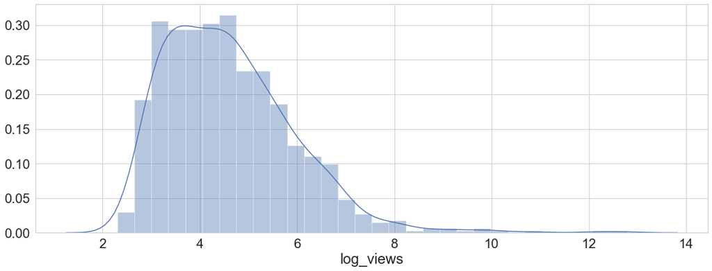

```python
sns.set(
    font_scale=2,
    style="whitegrid",
    rc={'figure.figsize':(20,7)}
        )

sns.distplot(views_per_ad.log_views)
```

#### Задача 3. А теперь давайте посчитаем скользящее среднее показов с окном 2. Какое значение скользящего среднего получим за 6 апреля 2019 года? (ответ округлите до целых)?

```python
ads_view_per_data = ads_data.query('event == "view"') \
                            .pivot_table(index='ad_id',
                                         columns='date',
                                         values='time',
                                         aggfunc='count')
```

```python
ads_view_per_data.head()
```

| date ad_id | 2019-04-01 | 2019-04-02 | 2019-04-03 | 2019-04-04 | 2019-04-05 | 2019-04-06 |
| --- | --- | --- | --- | --- | --- | --- |
| 2 | 83.0 | 18.0 | NaN | NaN | NaN | NaN |
| 3 | 158.0 | 26.0 | NaN | NaN | NaN | NaN |
| 1902 | NaN | NaN | 34.0 | 7.0 | NaN | NaN |
| 2064 | NaN | 28.0 | 7.0 | NaN | NaN | NaN |
| 2132 | NaN | NaN | 25.0 | 27.0 | 6.0 | NaN |

```python
mean_view = ads_view_per_data.mean()
```

```python
rolling_view = mean_view.rolling(2).mean()
```

```python
rolling_view['2019-04-06'].round()
```

```
598.0
```

Ответ: 598

#### Задача 4. Скользящее среднее часто используется для поиска аномалий в данных. Давайте попробуем нанести на один график значения арифметического среднего по дням и скользящего среднего количества показов. Посчитайте, в какой день наблюдается наибольшая разница по модулю между арифметическим средним и скользящим средним (дни, в которых скользящее среднее равно NaN не учитываем)? (Ответ запишите во формате yyyy-MM-dd)

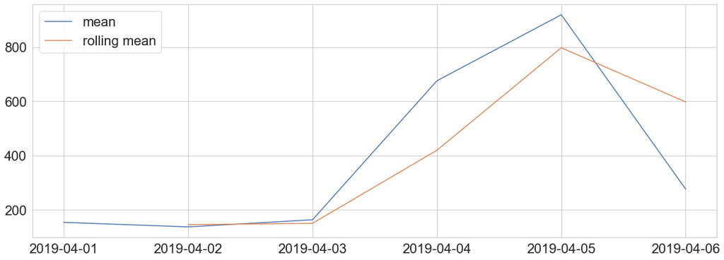

```python
sns.lineplot(data=mean_view, label='mean')
sns.lineplot(data=rolling_view, label='rolling mean')
```

```python
anomaly_day = (mean_view - rolling_view).abs().idxmax()
```

```python
anomaly_day
```

```
'2019-04-06'
```

Ответ: 2019-04-06

#### Задача 5. Напишите функцию, которая найдет проблемное объявление (с наибольшим/наименишим количеством показов) в день, в который была замечена самая большая по модулю аномалия. (Задание со звездочкой)*

```python
difference_value = (mean_view - rolling_view)[anomaly_day]
```

```python
if difference_value <= 0:
    anomaly_ad = ads_view_per_data[anomaly_day].idxmax()
else:
    anomaly_ad = ads_view_per_data[anomaly_day].idxmax()
```

```python
anomaly_ad
```

```
112583
```

### Пишем функцию по поиску ид объявления

```python
def find_anomalu_id(ad_view_per_day_per_add):
    mean_view = ad_view_per_day_per_add.mean()

    anomaly_day = (mean_view - rolling_view).abs().idxmax()

    difference_value = (mean_view - rolling_view)[anomaly_day]

    if difference_value <= 0:
        anomaly_ad = ad_view_per_day_per_add[anomaly_day].idxmax()
    else:
        anomaly_ad = ad_view_per_day_per_add[anomaly_day].idxmin()

    return anomaly_ad
```

```python
find_anomalu_id(ads_view_per_data)
```

```
112583
```

Ответ: проблемное объявление в этот день 112583

#### Задача 6. Теперь подгрузим данные по рекламным клиентам и найдем среднее количество дней от даты создания рекламного клиента и первым запуском рекламного объявления этим клиентом.

```python
full_data = ads_data.merge(ads_clients_data.drop(columns=['date', 'community_id']))
full_data.head()
```

|  | date | time | event | platform | ad_id | client_union_id | campaign_union_id | ad_cost_type | ad_cost | has_video | target_audience_count | create_date |
| --- | --- | --- | --- | --- | --- | --- | --- | --- | --- | --- | --- | --- |
| 0 | 2019-04-01 | 2019-04-01 00:00:48 | view | android | 45061 | 34734 | 45061 | CPM | 200.6 | 0 | 1955269 | 2018-12-04 |
| 1 | 2019-04-01 | 2019-04-01 00:03:28 | view | android | 45061 | 34734 | 45061 | CPM | 200.6 | 0 | 1955269 | 2018-12-04 |
| 2 | 2019-04-01 | 2019-04-01 00:04:58 | view | ios | 45061 | 34734 | 45061 | CPM | 200.6 | 0 | 1955269 | 2018-12-04 |
| 3 | 2019-04-01 | 2019-04-01 00:10:23 | view | ios | 45061 | 34734 | 45061 | CPM | 200.6 | 0 | 1955269 | 2018-12-04 |
| 4 | 2019-04-01 | 2019-04-01 00:15:42 | view | android | 45061 | 34734 | 45061 | CPM | 200.6 | 0 | 1955269 | 2018-12-04 |

```python
full_data[['date', 'create_date']] = full_data[['date', 'create_date']].apply(pd.to_datetime)
```

```python
def find_minimum_diff(group):                  # создаем именнованную функцию вместо lymbda
    diff = group.date - group.create_date
    return diff.min()
```

```python
full_data \
    .groupby('client_union_id') \
    .apply(find_minimum_diff) \
    .mean()
```

```
Timedelta('124 days 09:04:43.532219')
```

Ответ: 124 дня

```python
# apply(lambda group: (group.date - group.create_date).min())
```

#### Задача 7. Давайте вычислим конверсию из создания рекламного клиента в запуск первой рекламы в течение не более 365 дней. Ответ дайте в процентах и округлите до сотых. (Фильтровать нужно по значению в формате pd.Timedelta(365, unit='d'))

```python
creation_difference = full_data \
    .groupby('client_union_id') \
    .apply(find_minimum_diff) \
```

```python
treshold = pd.to_timedelta(365, unit='d')
treshold
```

```
Timedelta('365 days 00:00:00')
```

```python
creation_difference = creation_difference.loc[creation_difference < treshold]
```

```python
round(creation_difference.shape[0] / ads_clients_data.client_union_id.nunique() * 100, 2)
```

```
0.69
```

Ответ: 0.69%

##### Задача 8. Давайте разобъем наших клиентов по промежуткам от создания до запуска рекламного объявления, равным 30. Определите, сколько уникальных клиентов запустили свое первое объявление в первый месяц своего существования (от 0 до 30 дней). Список промежутков для метода pd.cut [0, 30, 90, 180, 365]

```python
# переведем нужные интервалы в формат timedelta с помощью метода pd.to_timedelta
bins = pd.to_timedelta([0, 30, 90, 180, 365], unit='d')
```

```python
pd.cut(creation_difference,
       bins=bins,
       labels=['0-30', '30-90', '90-180', '180-365']) \
       .value_counts()
```

```
90-180     396
30-90      263
180-365    168
0-30        11
dtype: int64
```

```python
creation_difference_group = pd.cut(creation_difference,
       bins=bins,
       labels=['0-30', '30-90', '90-180', '180-365'])
```

```python
creation_difference_group.value_counts()
```

```
90-180     396
30-90      263
180-365    168
0-30        11
dtype: int64
```

Ответ: 11 клиентов

#### Задача 9. А теперь давайте выведем на интерактивный график эти категории с количеством уникальных клиентов в них.

```python
import plotly.express as px
```

```python
fig = px.bar(creation_difference_group)
fig.show()
```

[interactive chart not shown]